# Лабораторная работа 2. Классификация.

## Цель работы

Изучение метода k ближайших соседей, наивного байесовского алгоритма и метода опорных векторов для задач классификации.

## Исходные данные

В качестве исходных данных будут использованы сгенерированные с помощью функции make_blobs библиотеки sklearn данные. Необходимо классифицировать сгенерированные объекты с помощью метода k-ближайших соседей, наивного байесовского алгоритма и метода опорных векторов

```python
from sklearn.datasets import make_blobs
import matplotlib.pyplot as plt
from sklearn.neighbors import KNeighborsClassifier
from sklearn.svm import SVC
from sklearn.naive_bayes import GaussianNB
import numpy as np
import math
```

### Генерация данных с использованием make_blobs

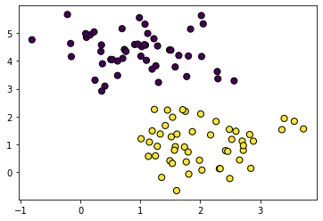

```python
n = 100
X, y = make_blobs(n_samples = n, centers = 2, n_features = 2, random_state = 0, cluster_std = 0.7)
plt.scatter(X[:, 0], X[:, 1], marker = 'o', c = y, s = 50, edgecolor = 'k')
plt.show()
```

### Суть метода k-ближайших соседей

Метод k ближайших соседей (англ. k-nearest neighbor algorithm) - метод автоматической классификации объектов. Основным принципом метода ближайших соседей является то, что объект присваивается тому классу, который является наиболее распространённым среди соседей данного элемента.

Соседи берутся исходя из множества объектов, классы которых уже известны, и, исходя из ключевого для данного метода значения k высчитывается, какой класс наиболее многочислен среди них.

### Суть наивного байесовского алгоритма

Наивный байесовский алгоритм — это вероятностный алгоритм машинного обучения, основанный на применении теоремы Байеса и используемый в самых разных задачах классификации.

$$ P(A|B)=\frac{P(B|A)*P(A)}{P(B)}\\ $$

- P(A|B) - вероятность гипотезы А при наступлении события В, т. е. вероятность А, когда В уже верно;
- P(B|A) - вероятность наступления события В, если гипотеза А верна;
- P(A) - вероятность того, что гипотеза А верна;
- P(B) - вероятность наступления события В;

### SVM

Метод опорных векторов (Support Vector Machine - SVM) относится к группе граничных методов. Она определяет классы при помощи границ областей.

При помощи данного метода решаются задачи бинарной классификации.

В основе метода лежит понятие плоскостей решений.

Плоскость (plane) решения разделяет объекты с разной классовой принадлежностью.

### Реализация метода kNN

```python
def methodknn(traindata, testdata, k, numberofclasses):
    def distance(x,y):
        return math.sqrt((x[0] - y[0])**2 + (x[1] - y[1])**2)
    ans = []
    for testpoint in testdata:
        testdist = [[distance(testpoint,traindata[i]), int(traindata[i][2])] for i in range(len(traindata))]
        stat = [0 for i in range(numberofclasses)]
        for d in sorted(testdist)[0:k]:
            stat[d[1]] += 1
        ans.append(sorted(zip(stat, range(numberofclasses)),reverse=True)[0][1])
    return ans
```

```python
ycopy = y.reshape(n,1)
traindata = np.hstack([X,ycopy])
testdata = [[3, 0], [2, 5], [2, 2]]
```

```python
answer = methodknn(traindata, testdata, 5, 2)
answer
```

```
[1, 0, 1]
```

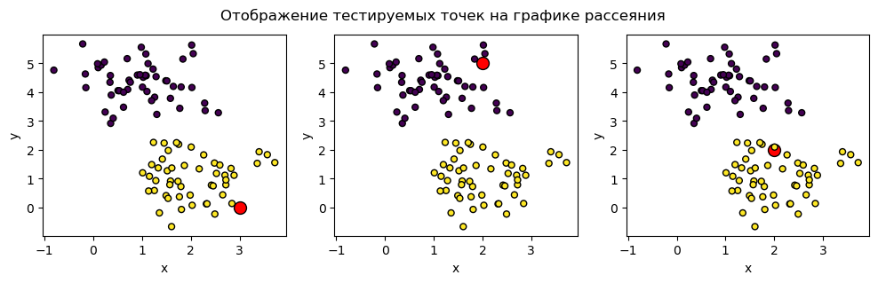

```python
fig, axes = plt.subplots(1, 3, figsize = (12, 3), dpi = 100)


for j in range(3):
    axes[j].scatter(testdata[j][0], testdata[j][1], marker = 'o', c = 'r', s = 100, edgecolor = 'k')
    axes[j].scatter(X[:, 0],X[:, 1], marker = 'o', c = y, s = 25, edgecolor = 'k')
    axes[j].set_ylabel('y')
    axes[j].set_xlabel('x')

fig.suptitle('Отображение тестируемых точек на графике рассеяния')
plt.show()
```

# kNN с помощью библиотеки Scikit-learn [2]

```python
neigh = KNeighborsClassifier(n_neighbors=5)
neigh.fit(X, y)
print(neigh.predict(testdata))
print(neigh.predict_proba(testdata))
```

```
[1 0 1]
[[0. 1.]
 [1. 0.]
 [0. 1.]]
```

# SVM с помощью библиотеки Scikit-learn [3]

```python
clf = SVC()
clf.fit(X, y)
clf.predict(testdata)
```

```
array([1, 0, 1])
```

# GaussianNB с помощью библиотеки Scikit-learn [4]

```python
clf = GaussianNB()
clf.fit(X, y)
clf.predict(testdata)
```

```
array([1, 0, 1])
```

# Вывод

В результате работы была разработана функция, реализующуя алгоритм k ближайших соседей для определения объекта к одному из двух сгенерированных классов исходных данных. Удалось применить разработанную функцию для определения класса 3-х объектов. Также была произведена графическая визуализация классифицируемого объекта на картинке с исходными данными [1].

Были использованы возможности библиотеки scikit-Learn [2] для решения задачи классификации тех же объектов.

Результаты определения класса объектов, полученные путём scikit-learn и созданной функции, равны в пределах погрешности.

Также были рассмотрены классификаторы GNB и SVC. Они показали схожие результаты в рамках рассмотренной задачи.

# Список литературы

1. Описание функции make-blobs https://scikit-learn.org/stable/modules/generated/sklearn.datasets.make_blobs.html
2. Описание функции KNeighborsClassifier https://scikit-learn.org/stable/modules/generated/sklearn.neighbors.KNeighborsClassifier.html
3. Описание Support Vector Machines https://scikit-learn.org/stable/modules/svm.html
4. Описание Gaussian Naive Bayes https://scikit-learn.org/stable/modules/naive_bayes.html